# DATASCI 185: Introduction to AI Applications

Lecture 03: Dataset Design, Labels, and Tasks

Danilo Freire

danilo.freire@emory.edu

Department of Data and Decision Sciences  
Emory University

# Welcome back! 🤓

## Recap of last class

- We traced AI from Ancient Greece to modern transformers
- Symbolic AI (1950s-1980s): Hand-coded rules and logic
- AI Winters: When hype exceeded reality (twice!)
- Neural networks: From perceptrons to deep learning
- The data revolution: “Simple models + lots of data beat complex models with less data”
- Transformers (2017): Attention is all you need!
- Data became the new oil… but where do the data come from? 🤔

## Lecture overview

### Today’s agenda

- Today we’ll explore the foundation of all AI systems: the data they’re trained on
- Why data quality matters
- Types of ML tasks
- Sourcing and collecting data
- Selection bias and its dangers
- Best practices for labeling data
- Working with multiple annotators
- Quality control in datasets

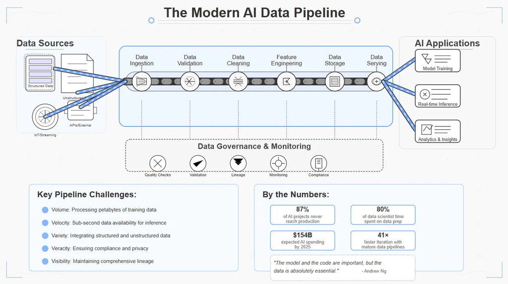

The Modern Data Pipeline

Source: [Medium](https://blog.dataengineerthings.org/the-ai-revolution-is-nothing-without-data-pipelines-288f1dfd8ca0)

## Tweet of the day

[figure not shown]

## What matters more?

### Take a moment to think…

> **“If you had to choose, which would give you better AI predictions?”**

**Option A:** 🧠

A state-of-the-art algorithm trained on low-quality data

**Option B:** 📊

A simple algorithm trained on high-quality data

**Discuss with your neighbour for 1 minute!**

**Raise your hand if you think Option A is better**

**And now raise your hand if you think Option B is better**

## A cow, a camel or a polar bear?

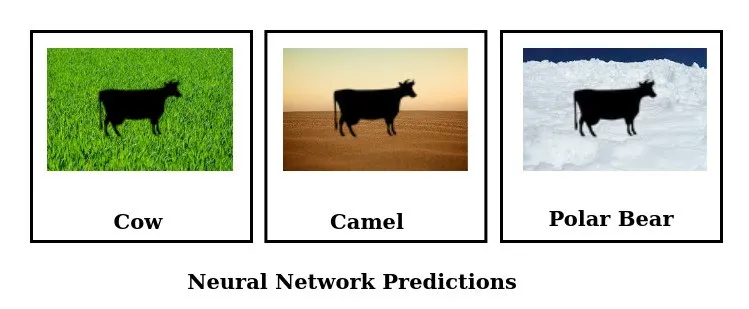

Source: [Medium](https://urwamuaz.medium.com/neural-networks-fail-on-data-with-spurious-correlation-b5010b107c32)

# Why data quality matters 📊

## Garbage in, garbage out

### The fundamental principle

- AI models are only as good as the data they’re trained on
- No amount of algorithmic sophistication can fix bad data
- Common data problems:
  - Missing important information (e.g., age, income, etc.)
  - Conflicting labels or formats (e.g., “yes” vs “1”)
  - Biases, not representative of reality (e.g., gender, race, etc.)
- The quality of your models is directly tied to the quality of your data (that’s true for humans too!)

[figure not shown]

Garbage In, Garbage Out

Source: [xkcd](https://xkcd.com/1838/)

## The data-centric AI movement

### A paradigm shift

- Traditional ML: Fix the data, improve the model
- Data-centric AI: Fix the model, improve the data
  - Check the website: https://datacentricai.org/
- Andrew Ng’s insight (2021):

> “Instead of focusing on the code, companies should focus on developing the processes to get and maintain good data.”
- For many real-world problems, improving data quality beats improving algorithms
- This is especially true when you have limited data

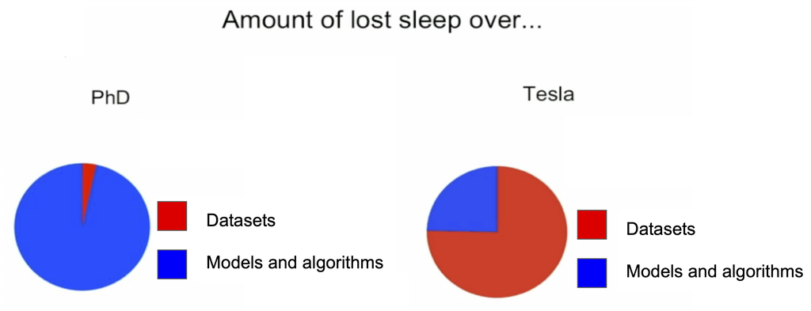

Model-centric vs. Data-centric AI

Source: [Andrej Karpathy](https://vimeo.com/274274744)

## Real-world impact of data quality

### The hidden costs of bad data

[figure not shown]

Source: [Harvard Business Review](https://hbr.org/2016/09/bad-data-costs-the-u-s-3-trillion-per-year)

## Real-world impact of data quality

### When bad data causes harm

| Case | What went wrong | Impact |
| --- | --- | --- |
| Credit scoring | Data reflected historical gender-based income gaps | Lower credit limits for women with similar profiles |
| Facial recognition | Training data mostly light-skinned faces | Error rates 34x higher for dark-skinned women |
| Criminal risk assessment | Historical arrest data reflected biased policing | Perpetuated racial disparities in sentencing |
| Hiring AI | Trained on historical (male-dominated) hiring decisions | Penalised female candidates |

> These weren’t algorithm failures—they were data failures.

# Types of machine learning tasks 🎯

## Classification tasks

### Predicting categories

- **Goal**: Assign inputs to discrete categories
- Examples:
  - Email → Spam or Not Spam
  - Image → Cat, Dog, Bird, etc.
  - Medical scan → Cancerous or Benign
  - Text → Positive, Negative, Neutral sentiment
- **Binary classification**: Two classes
- **Multi-class**: Many classes (one per input)
- **Multi-label**: Multiple labels per input
- Key challenge: How do you define the classes?

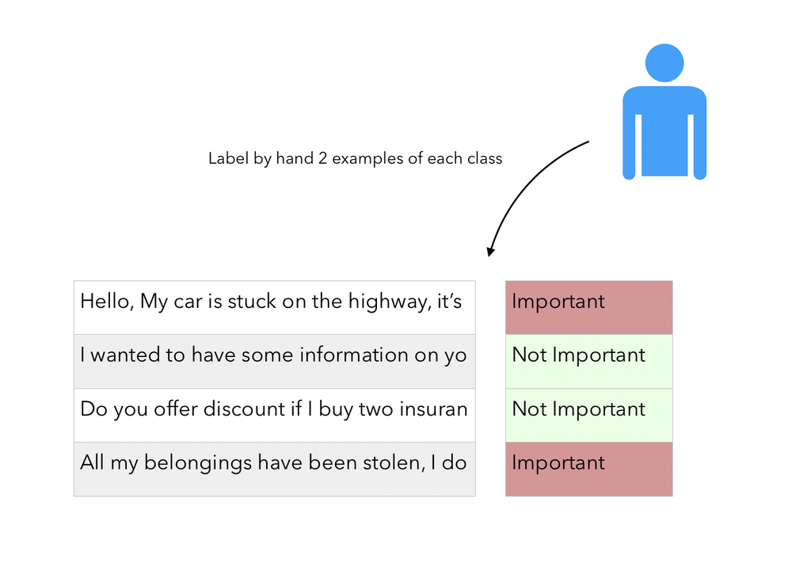

Classification: Assigning categories

Source: [Maël Fabien](https://maelfabien.github.io/machinelearning/NLP_5/)

## Regression tasks

### Predicting continuous values

- **Goal**: Predict a continuous numerical value
- Examples:
  - Features → House price
  - Patient data → Length of hospital stay
  - Weather data → Temperature tomorrow
  - User behaviour → Ad click probability
- Key question: What should the model predict?
- The choice of target variable is a design decision
- Different targets can lead to very different models

[figure not shown]

Regression: Predicting numbers

Source: [Our World in Data](https://ourworldindata.org/data-insights/people-in-richer-countries-tend-to-say-they-are-more-satisfied-with-their-lives)

## Other common ML tasks

### Beyond classification and regression

| Task | Description | Example |
| --- | --- | --- |
| **Object Detection** | Find and locate objects in images | Self-driving cars detecting pedestrians |
| **Segmentation** | Label every pixel in an image | Medical imaging (tumour boundaries) |
| **Sequence Labeling** | Label each element in a sequence | Named entity recognition in text |
| **Generation** | Create new content | ChatGPT, DALL-E, music generation |
| **Ranking** | Order items by relevance | Search results, recommendations |

Each task requires different types of labels in your dataset!

## Defining your classes

### Classification pitfalls

- Classes should be:
  - **Mutually exclusive**: No overlap
  - **Collectively exhaustive**: Cover all cases
  - **Consistently definable**: Clear boundaries
- Common problems:
  - Ambiguous categories: What counts as “spam”?
  - Subjective judgments: Is this review “positive”?
  - Cultural differences: What’s “offensive” varies
  - Evolving definitions: Categories change over time
- Solution: Clear annotation guidelines

[figure not shown]

A duck or a rabbit?

Source: [The Independent](https://www.independent.co.uk/news/science/duck-and-rabbit-illusion-b1821663.html)

## The proxy problem

### When labels don’t measure what you care about

- Often we can’t directly measure what we want to predict
- We use proxy variables instead…but proxies can be misleading!
- **Example 01: Predicting “health needs”**
- What we want: How sick is this patient?
- Available data: Healthcare spending
- What do you think of this proxy?
- Spending ≠ health needs
- Black patients had less spent on them due to systemic barriers
- Algorithm learned: “Black patients need less care” → Wrong!
- Always ask: Does this label actually measure what I care about?
- **Example 02: Predicting expertise on social media**
- What we want: Who is an expert in a field?
- Available data: Number of followers
- What do you think of this proxy?
- Followers ≠ Expertise
- Popularity can be gamed or unrelated to domain knowledge
- Algorithm learned: “High engagement = High expertise” → Wrong!

# Sourcing and collecting data 📥

## Where do the data come from?

### Common data sources

| Source | Examples | Considerations |
| --- | --- | --- |
| **Existing databases** | Hospital records, transaction logs | May have missing fields, inconsistent formats |
| **Public datasets** | ImageNet, Wikipedia, Common Crawl | May not match your specific domain |
| **Web scraping** | Social media, news articles | Legal and ethical concerns |
| **Surveys/Forms** | User feedback, questionnaires | Response bias, sampling issues |
| **Sensors/IoT** | Cameras, wearables, satellites | Privacy concerns, data volume |
| **Synthetic data** | Generated by other models | May not capture real-world complexity |

## How much data do you need?

### The million-dollar question

- There’s no universal answer… it depends on:
  - Task complexity
  - Number of classes/features
  - Model architecture
  - Required accuracy
- **Rule of thumb**: Start small, then scale
- **Scaling laws**: Performance improves predictably with more data:

$$\log(\text{error}) = -a \cdot \log(n) + b$$

- You can estimate how much data you’ll need by training on subsets and extrapolating

[figure not shown]

Performance vs. dataset size

Source: [Our World in Data](https://ourworldindata.org/grapher/ai-performance-knowledge-tests-vs-dataset-size)

# Selection bias ⚠️

## What is selection bias?

### When your data doesn’t represent reality

- Selection bias is the systematic deviation between your training data and the real-world distribution
- Also called: confounding, distribution shift, sampling bias
- The model learns patterns that won’t generalise
- Extremely hard to fix after the fact
- Prevention is better than cure!
- Always ask: “In what ways might my data not be representative?”

[figure not shown]

Selection bias

Source: [Wikipedia](https://en.wikipedia.org/wiki/Survivorship_bias)

## Common causes of selection bias

### Where does bias creep in?

| Type | Description | Example |
| --- | --- | --- |
| **Time bias** | Data from the past applied to the future | Training on 2019 data for 2024 predictions |
| **Location bias** | Data from one place applied elsewhere | US healthcare model used in India |
| **Demographics bias** | Certain groups under/over-represented | Clinical trial with mostly young, white, male participants |
| **Availability bias** | Using convenient rather than representative data | Surveying only friends |
| **Response bias** | Who responds differs from who doesn’t | Online surveys miss offline populations |
| **Long-tail bias** | Rare events underrepresented | Self-driving cars: unusual scenarios |

- Try it out: Generate an image of “a CEO” and “a nurse” using two different LLMs, such as [Qwen](https://qwen.ai/) and [Gemini](https://gemini.ai/). What do you notice?

## Prompt: Create an image of a CEO and a nurse

[figure not shown]

Qwen

Source: [Qwen](https://qwen.ai/) via [nanoGPT](https://nano-gpt.com)

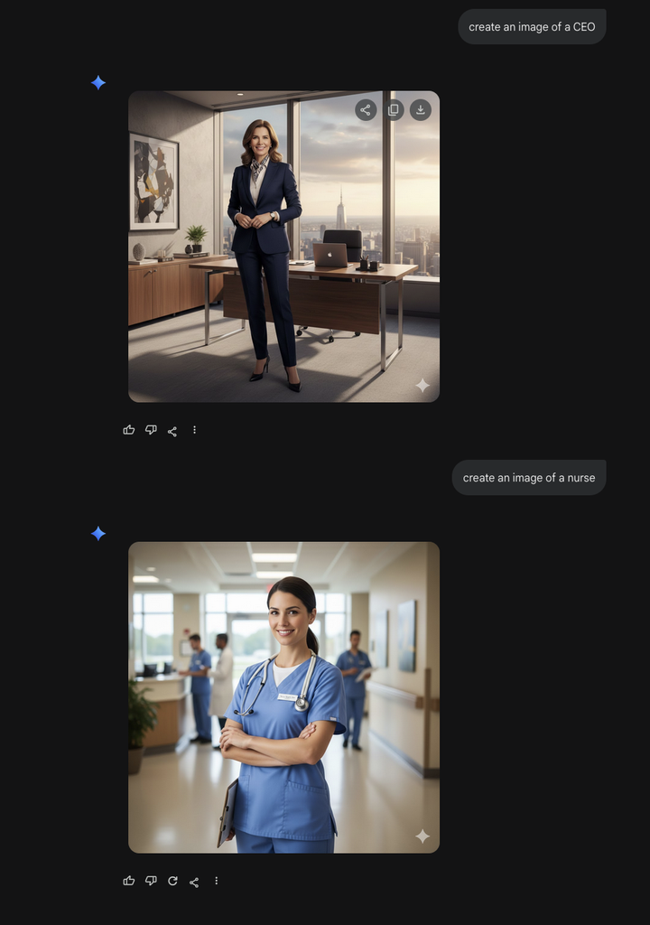

Gemini

Source: [Gemini’s NanoBanana](https://gemini.google.com)

## Dealing with selection bias

### Mitigation strategies

**After collection:**

- Use representative validation sets
- If data changes over time: hold out recent data for validation
- If deploying in new locations: validate on location-specific data
- Document known limitations of your dataset

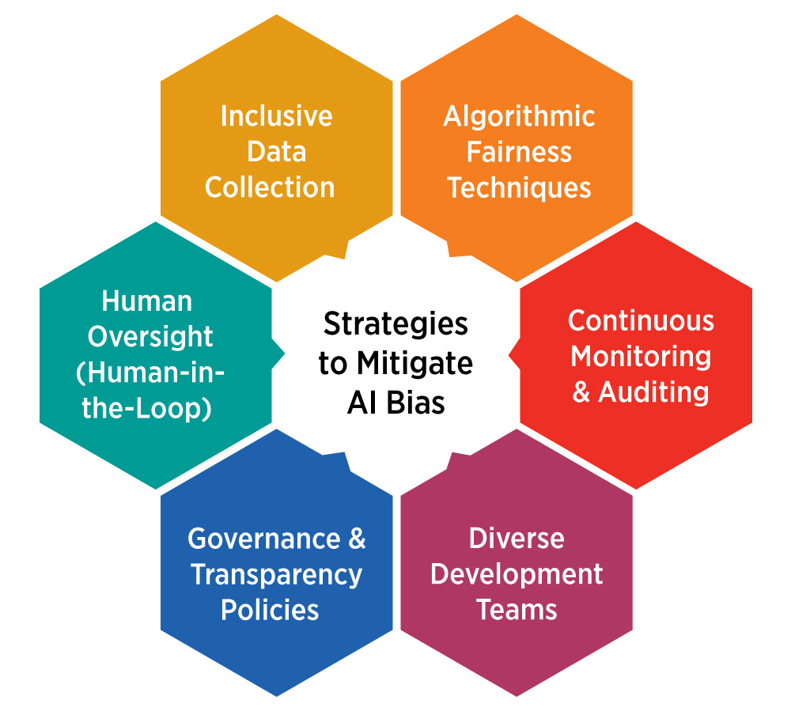

Strategies to reduce bias

Source: [WisdomPlexus](https://wisdomplexus.com/blogs/ai-bias-in-action-real-world-examples-and-mitigation-strategies/)

# Labelling data 🏷️

## Why labelling is hard

### The human bottleneck

- Most ML requires labeled data
- Labels come from humans → humans make mistakes
- Common issues:
  - **Inconsistency**: Different people label differently
  - **Ambiguity**: Some examples are genuinely unclear
  - **Mislabelling**: Human errors happen
  - **Fatigue**: Quality drops over time
  - **Expertise**: Some tasks need domain experts
- Labelling is expensive and time-consuming
  - See [Alex Wang’s Scale AI](https://scale.com/)
- Quality control is super important!

[figure not shown]

Labelling is harder than it looks!

Source: [Galliot](https://galliot.us/blog/data-labeling-approaches-challenges-tools/)

## Example

[figure not shown]

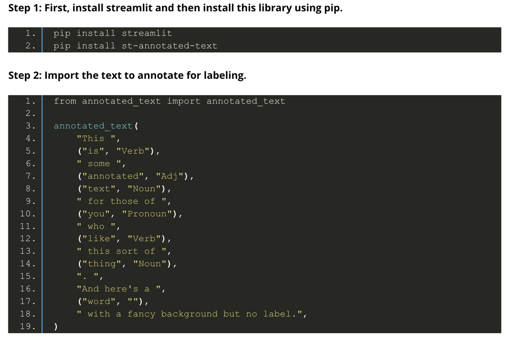

Source: [LeewayHertz](https://www.leewayhertz.com/data-annotation/)

## Be the annotator! 🏷️

### Try labelling these examples yourself

**Instructions**: For each example, decide on the label. Discuss with your neighbours!

### Example 1: Email Spam Detection

> “Congratulations! You’ve been selected to receive a $50 Amazon gift card for completing our customer satisfaction survey. Click here: surveyrewards-amazon.com”

**Is this SPAM or NOT SPAM?**

### Example 2: Sentiment Analysis

> “The hotel room was clean and the location was perfect. However, the staff were incredibly rude and the WiFi didn’t work at all. I probably won’t stay here again.”

**Is this POSITIVE, NEGATIVE, or NEUTRAL?**

### Example 3: Content Moderation

> “This politician is an absolute moron who doesn’t understand basic economics.”

**Should this be REMOVED or ALLOWED?**

## MNIST dataset

- How would you label these images?

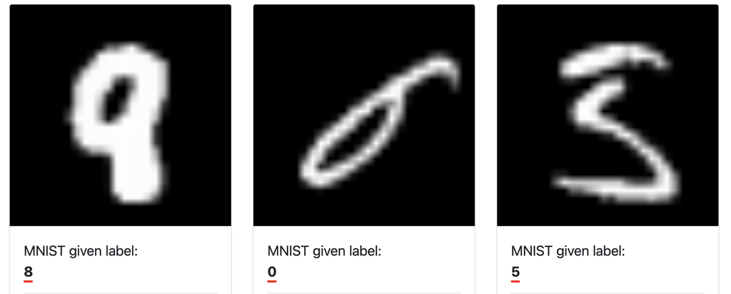

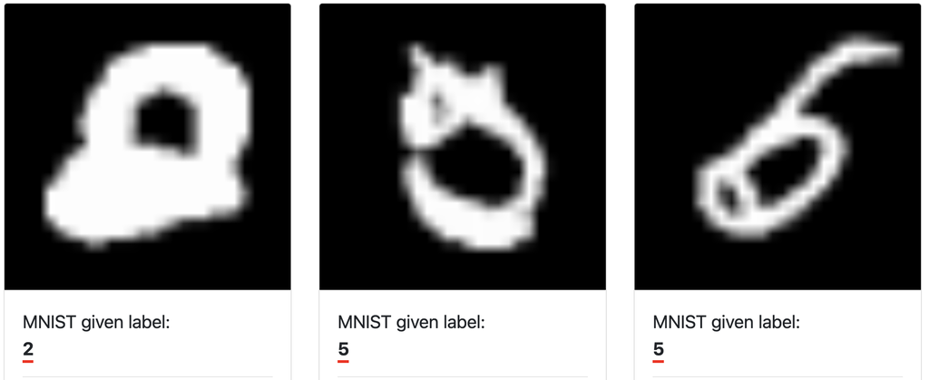

Source: https://labelerrors.com/

## Writing good annotation guidelines

### The foundation of quality labels

Good guidelines should include:

1. **Clear definitions**: What does each label mean?
2. **Examples**: Canonical cases for each class
3. **Counter-examples**: What does NOT belong
4. **Edge cases**: How to handle ambiguity
5. **Visual aids**: Screenshots, annotated examples

Best practices:

- Test guidelines with a small group first
- Iterate based on confusion and disagreements
- Keep guidelines living documents—update as needed

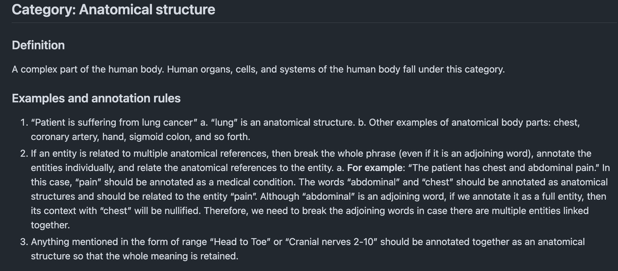

Source: [Google’s Healthcare Text Annotation Guidelines](https://github.com/google/healthcare-text-annotation/blob/master/guidelines/defining-entity-categories.md)

## Why use multiple annotators?

### Reducing individual errors

- Individual annotators make mistakes
- Multiple annotators → more reliable labels
- Benefits:
  - Catch errors through disagreement
  - Identify genuinely ambiguous cases
  - Assess label quality/confidence
  - Reduce individual biases
- Trade-off: More expensive (each example labeled multiple times)
- **Majority vote**: Most common label wins
- Limitations:
  - How to break ties?
  - All annotators weighted equally (bad and good)
  - Doesn’t capture uncertainty
- **Weighted voting**: Trust reliable annotators more

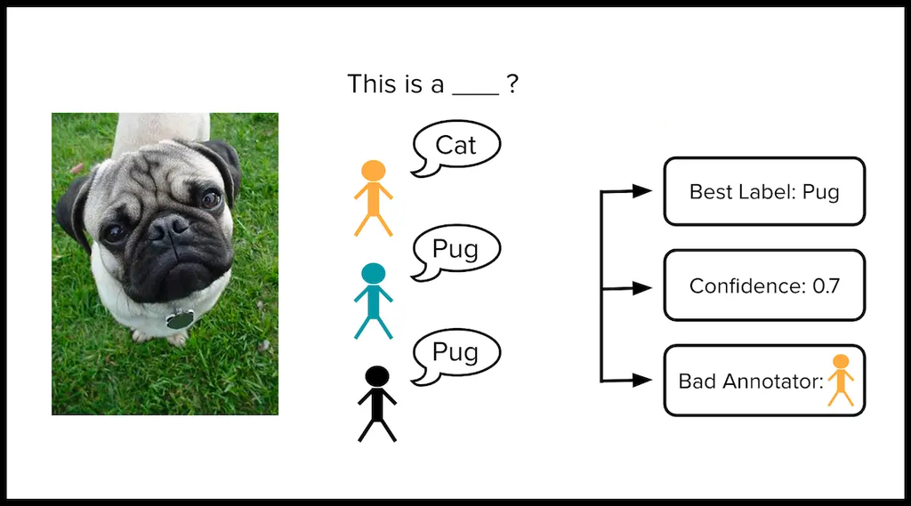

Multiple perspectives improve quality

Source: [MIT’s DataCentric AI course](https://dcai.csail.mit.edu/2023/dataset-creation-curation/)

## Inter-annotator agreement (IAA)

### Measuring labelling quality

- Inter-annotator agreement: Do annotators agree with each other?
- High agreement → Labels are reliable
- Low agreement → Problem with guidelines or task

**Common metrics:**

- **Percent agreement**: Simple but misleading
- [Cohen’s Kappa](https://en.wikipedia.org/wiki/Cohen%27s_kappa): Accounts for chance agreement (2 annotators)
- [Fleiss’ Kappa](https://en.wikipedia.org/wiki/Fleiss%27s_kappa) or [Krippendorff’s alpha](https://en.wikipedia.org/wiki/Krippendorff%27s_alpha): Multiple annotators

$$\kappa = \frac{p_o - p_e}{1 - p_e}$$

- $p_o$ = observed agreement
- $p_e$ = expected agreement by chance

| Kappa | Interpretation |
| --- | --- |
| < 0 | Poor |
| 0.0–0.20 | Slight |
| 0.21–0.40 | Fair |
| 0.41–0.60 | Moderate |
| 0.61–0.80 | Substantial |
| 0.81–1.00 | Almost perfect |

## Example: Computing Cohen’s Kappa

### A worked example

**Two annotators label 100 emails as Spam/Not Spam:**

|  | Bob: Spam | Bob: Not Spam | **Total** |
| --- | --- | --- | --- |
| **Alice: Spam** | 20 | 5 | 25 |
| **Alice: Not Spam** | 10 | 65 | 75 |
| **Total** | 30 | 70 | **100** |

**Step 1: Observed agreement ($p_o$)**

- Agreed on 20 + 65 = 85 emails
- $p_o = 85/100 = 0.85$

**Step 2: Expected agreement by chance ($p_e$)**

- Alice: 25/100 = 0.25 Spam, 75/100 = 0.75 Not Spam
- Bob: 30/100 = 0.30 Spam, 70/100 = 0.70 Not Spam
- P(both say Spam) = $0.25 \times 0.30 = 0.075$
- P(both say Not Spam) = $0.75 \times 0.70 = 0.525$
- $p_e = 0.075 + 0.525 = 0.60$

**Step 3: Calculate Kappa ($\kappa$)**

$$\kappa = \frac{0.85 - 0.60}{1 - 0.60} = \frac{0.25}{0.40} = 0.625$$

Substantial agreement (0.61–0.80). Annotators agreed much more than expected by chance alone

## Resolving disagreements

### Strategies when annotators conflict

| Strategy | How it works | When to use |
| --- | --- | --- |
| **Majority voting** | Most common label wins | Quick and cheap |
| **Adjudication** | Expert makes final call | High-stakes decisions |
| **Discussion** | Annotators resolve together | Building consensus |
| **Weighted voting** | Trust reliable annotators more | Historical performance data |
| **Keep all labels** | Train model on disagreement | Research on uncertainty |

> The best strategy depends on your resources, timeline, and risk tolerance.

## Quality control

### The gold standard approach

- Quality control (QC) examples: Examples where you already know the correct answer
- Slip QC examples into the labelling queue
- Use them to:
  - Monitor annotator accuracy over time
  - Identify annotators who need retraining
  - Catch low-quality work early
- Important: Don’t let annotators know which examples are QC
- Flag annotators who fail too many QC checks

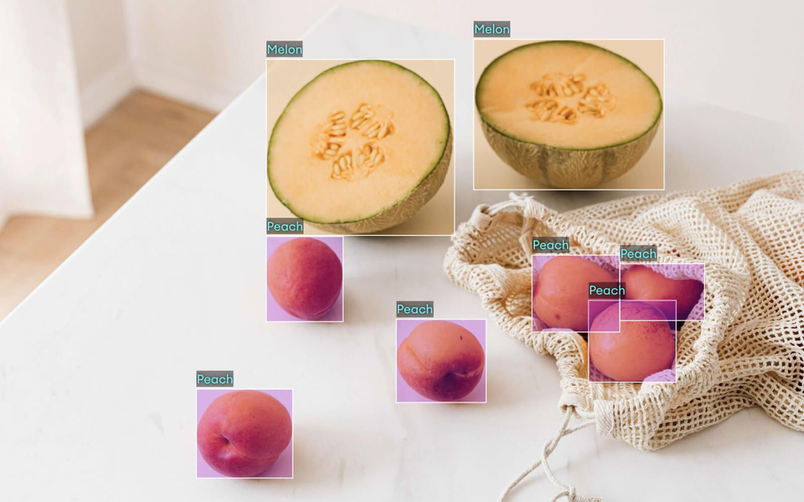

QC examples catch errors

Source: [SuperAnnotate](https://www.superannotate.com/blog/guide-to-data-labeling)

## Building a robust annotation pipeline

### End-to-end workflow

```
%%{init: {'theme': 'base', 'themeVariables': {'fontSize': '17px'}}}%%
flowchart TB
    A[📊 Data Selection] --> B[📝 Guideline Design]
    B --> C[👥 Annotator Training]
    C --> D[🧪 Pilot Labelling]
    D --> E{Quality OK?}
    E -->|No| B
    E -->|Yes| F[🏭 Full Labelling]
    F --> G[✅ QC Checks]
    G --> H[📈 Aggregation]
    H --> I[🎯 Final Dataset]
    style E fill:#f9f,stroke:#333,stroke-width:2px
    style I fill:#90EE90,stroke:#333,stroke-width:2px
```

**Key stages:**

1. **Select data** stratified by important subgroups
2. **Design guidelines** with clear definitions and examples
3. **Train annotators** and calibrate their judgments
4. **Pilot** on a small sample, iterate on guidelines
5. **Scale up** with ongoing quality control

# Summary ✅

## Main takeaways

- Data quality > Algorithm sophistication for most real-world problems
- Problem framing determines what data you need and how to label it
- Selection bias is a major source of error. Enumerate biases before collecting
- Labelling is hard, so clear guidelines and quality control are very important
- Multiple annotators improve reliability, but aggregate intelligently
- Document everything, so your future self will thank you

# … and that’s all for today! 🎉 See you soon! 😊